# Structure Learning a Bayesian Network given bike sharing data

Let’s start with importing the necessary libraries.

```r
# run the commented lines in the console to install the necessary packages
#if (!requireNamespace("BiocManager", quietly=TRUE))
#  install.packages("BiocManager")
#BiocManager::install("RBGL")
#install.packages(c("birankr", "SID", "sna", "bnlearn"))

# load the packages in the current session
library(birankr)
library(dagitty)
library(SID)
library(sna)
library(bnlearn)
```

Let’s now load the data from storage and determine the indices at which each day starts.

```r
# use hourly data as source
hourly.data <- read.csv("hour.csv", header=TRUE)
# determine indices of day starts
day.starts <- hourly.data$instant[!duplicated(hourly.data$dteday)]

write(sprintf("Number of days in the dataset: %d", length(day.starts)), stdout())
```

```
## Number of days in the dataset: 731
```

Now let’s make the hourly dataset a daily dataset by aggregating over the hour variable.

```r
data <- load.data()
```

Now that we have the data, let’s make sure that the types are correct.

```r
# scale all variables except the ordinal weather situation to z-scores
numeric.data <- data.frame(lapply(subset(data, select=-weathersit), as.numeric))
scaled.data <- data.frame(scale(numeric.data))

# put ordinal weather situation back in dataframes
data <- cbind(numeric.data, weathersit=data$weathersit)
scaled.data <- cbind(scaled.data, weathersit=data$weathersit)

# factorize the binary season, holiday, workingday, and rallyprotest variables
factor.data <- cbind(
  subset(scaled.data, select=-c(season, holiday, workingday, rallyprotest)),
  season=as.factor(data$season),
  holiday=as.factor(data$holiday),
  workingday=as.factor(data$workingday),
  rallyprotest=as.factor(data$rallyprotest)
)

# write variables and variable types to notebook
write("Variables in the daily dataset:", stdout())
```

```
## Variables in the daily dataset:
```

```r
for (var in colnames(factor.data)) {
  write(cat(var, ": ", class(factor.data[,var])), stdout())
}
```

```
## day :  numeric
## daylength :  numeric
## gasprice :  numeric
## hum :  numeric
## windspeed :  numeric
## temp :  numeric
## atemp :  numeric
## casual :  numeric
## registered :  numeric
## weathersit :  ordered factor
## season :  factor
## holiday :  factor
## workingday :  factor
## rallyprotest :  factor
```

### Manual

First, we initialize the manually constructed network to compare the automatically constructed networks to.

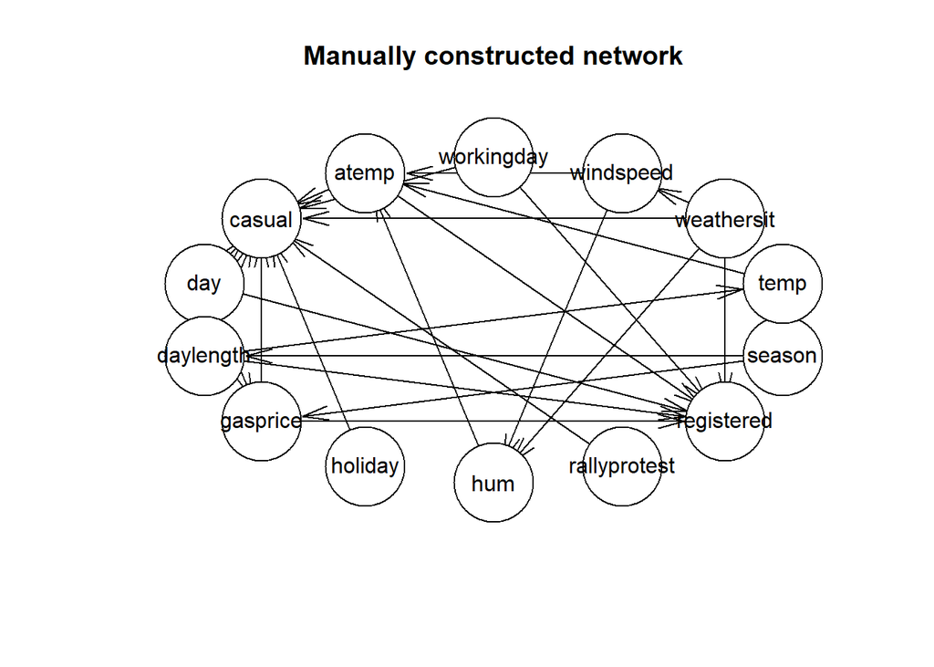

```r
# full Bayesian network is specified below using dagitty package
manual.g <- dagitty(paste('dag {',
    ####################################
    #            Variables             #
    ####################################
    # weather variables
    'weathersit [pos="-0.402,-0.329"]
    hum [pos="-0.412,-0.329"]
    windspeed [pos="-0.412,-0.337"]
    temp [pos="-0.421,-0.324"]
    atemp [pos="-0.421,-0.331"]',

    # day variables
    'season [pos="-0.428,-0.312"]
    day [pos="-0.422,-0.297"]
    workingday [pos="-0.402,-0.319"]
    holiday [pos="-0.403,-0.301"]',

    # extra variables
    'daylength [pos="-0.422,-0.316"]
    gasprice [pos="-0.422,-0.308"]
    rallyprotest [pos="-0.402,-0.308"]',

    # outcome variables
    'casual [pos="-0.412,-0.304"]
    registered [pos="-0.412,-0.321"]',

    ####################################
    #            Connections           #
    ####################################
    # weather relations
    'season -> daylength -> temp -> atemp
    weathersit -> {windspeed -> hum} -> atemp',

    # gas price relations
    '{season day} -> gasprice',

    # outcome relations
    '{day atemp workingday weathersit gasprice daylength holiday rallyprotest} -> casual
    {day atemp workingday weathersit gasprice daylength} -> registered',
'}'))
manual.g <- model2network(toString(manual.g, "bnlearn"))

# save network to list and plot the network
graphs[[1]][[1]] <- manual.g
plot(manual.g, main="Manually constructed network")
```

### Hill Climbing

We are finally ready to start trying out structure learning algorithms. First, we will try the hill climbing algorithm which learns structure based on a score.

```r
# reset list and set score functions that will be used
graphs <- graphs[1]
scores <- c("bic-cg", "pred-loglik-cg", "aic-cg", "loglik-cg")

# initialize data for pred-loglik-cg scoring function
set.seed(2020)
prop <- 0.8
cut <- nrow(data) %/% (1 / prop) + 1
factor.data100 <- factor.data[sample(nrow(data)),]
factor.data80 <- factor.data100[1:cut,]
factor.data20 <- factor.data100[(cut + 1):nrow(data),]

# run all algorithm variants
n.iters = 1  # number of networks learned per algorithm variant
random <- FALSE  # whether to use a random or empty initial DAG
run.networks(n.iters, 2 - random, hc, factor.data, score=scores[1])
run.networks(n.iters, 2 - random, hc, factor.data80, score=scores[2], newdata=factor.data20)
run.networks(n.iters, 2 - random, hc, factor.data, score=scores[3])
run.networks(n.iters, 2 - random, hc, factor.data, score=scores[4])
```

We will evaluate the learned networks based on metrics and the PageRanks of each node in the learned networks.

```r
# compute and show the metrics and PageRanks
titles <- c("manual", scores)
metrics <- graphsMetrics(titles); print(metrics)
```

```
##                  manual     bic.cg pred.loglik.cg     aic.cg  loglik.cg
## arcs         24.0000000 30.0000000     42.0000000 50.0000000 67.0000000
## SID           0.0000000 79.0000000     69.0000000 66.0000000 86.0000000
## SHD           0.0000000 40.0000000     45.0000000 47.0000000 61.0000000
## bestSIDidx    1.0000000  1.0000000      1.0000000  1.0000000  1.0000000
## bestSHDidx    1.0000000  1.0000000      1.0000000  1.0000000  1.0000000
## MECs          1.0000000  1.0000000      1.0000000  1.0000000  1.0000000
## DegreeC       0.4102564  0.3333333      0.2692308  0.2564103  0.2179487
## BetweennessC  0.4551282  0.5705128      0.3707265  0.9378205  0.4089744
## TP           24.0000000 15.0000000     17.0000000 19.0000000 20.0000000
## FP            0.0000000 15.0000000     25.0000000 31.0000000 47.0000000
## FN            0.0000000  9.0000000      7.0000000  5.0000000  4.0000000
## TN           67.0000000 52.0000000     42.0000000 36.0000000 20.0000000
## Precision     1.0000000  0.5000000      0.4047619  0.3800000  0.2985075
## Recall        1.0000000  0.6250000      0.7083333  0.7916667  0.8333333
## F1            1.0000000  0.5555556      0.5151515  0.5135135  0.4395604
## DDM           1.0000000 -0.3750000     -0.6250000 -0.7083333 -1.2916667
## BSF           1.0000000  0.4011194      0.3351990  0.3289801  0.1318408
```

```r
pageRanks <- graphsPageRanks(titles); print(pageRanks)
```

```
##                  manual     bic.cg pred.loglik.cg     aic.cg  loglik.cg
## day          0.01071429 0.01366978     0.01435714 0.01998957 0.01733217
## season       0.01071429 0.02253626     0.01071429 0.01071429 0.01733217
## holiday      0.01071429 0.01563279     0.01071429 0.01301585 0.01664972
## workingday   0.01071429 0.01735866     0.01071429 0.01624605 0.01743640
## daylength    0.01526786 0.01390692     0.01526786 0.01993451 0.01733217
## rallyprotest 0.01071429 0.01390692     0.01071429 0.01402775 0.01664972
## gasprice     0.01830357 0.03390339     0.04691933 0.04391287 0.13277849
## hum          0.01851228 0.01670549     0.01860714 0.01569028 0.02311805
## windspeed    0.01299107 0.01390692     0.01911942 0.01512448 0.02311805
## temp         0.01504018 0.02866360     0.02551719 0.03094201 0.02649549
## atemp        0.04475508 0.03208084     0.04154690 0.03381001 0.13277849
## casual       0.06992046 0.10175167     0.10215178 0.10212473 0.05919703
## registered   0.05170618 0.08884535     0.08408170 0.07520349 0.14743783
## weathersit   0.01071429 0.01071429     0.01071429 0.01071429 0.01733217
```

Finally, we will inspect the learned networks themselves. The learned network with the smallest SID metric of each algorithm variant is shown.

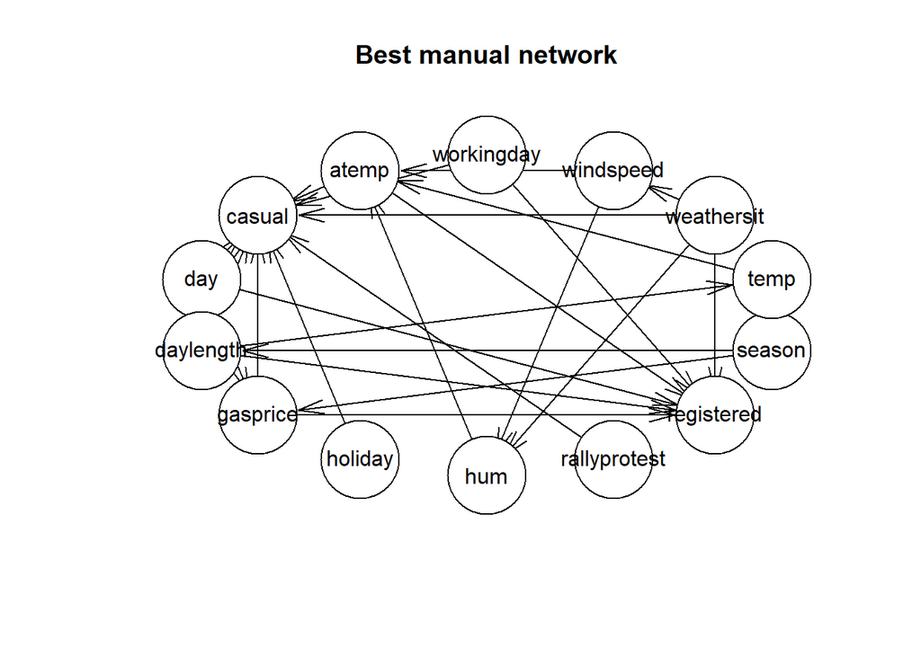

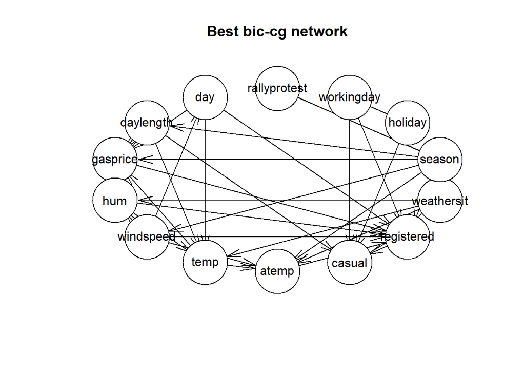

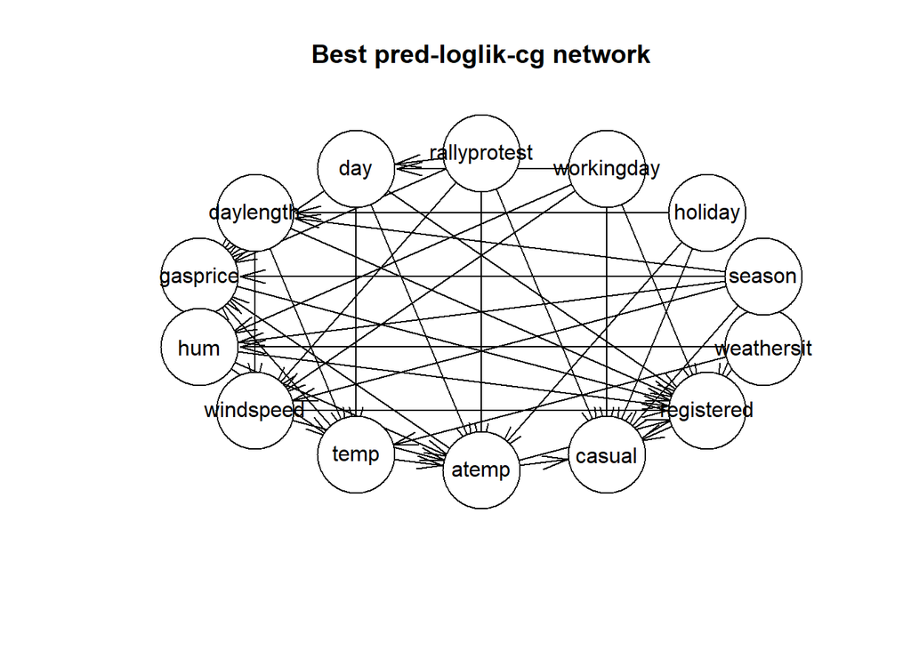

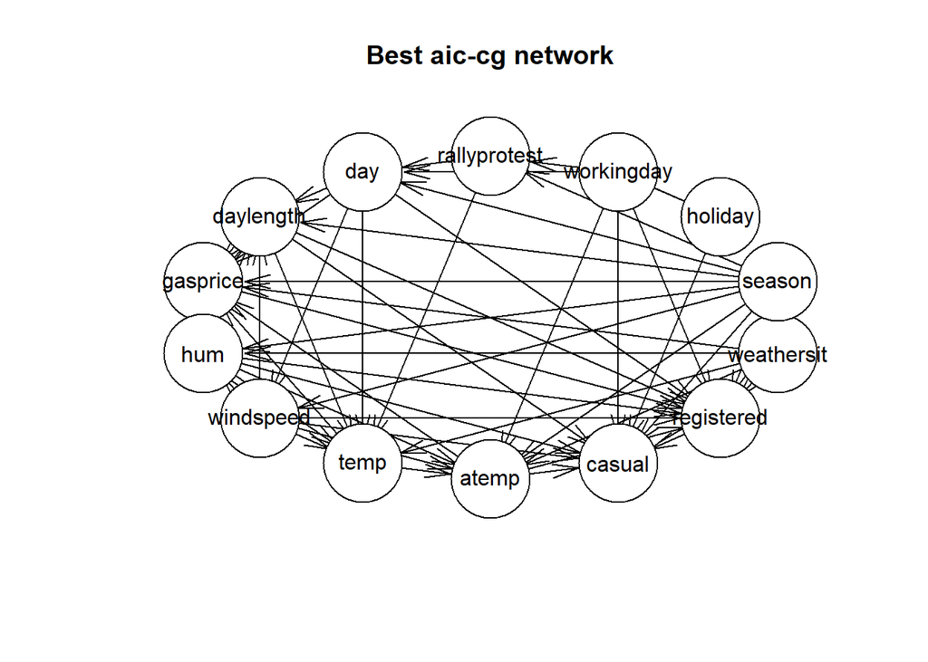

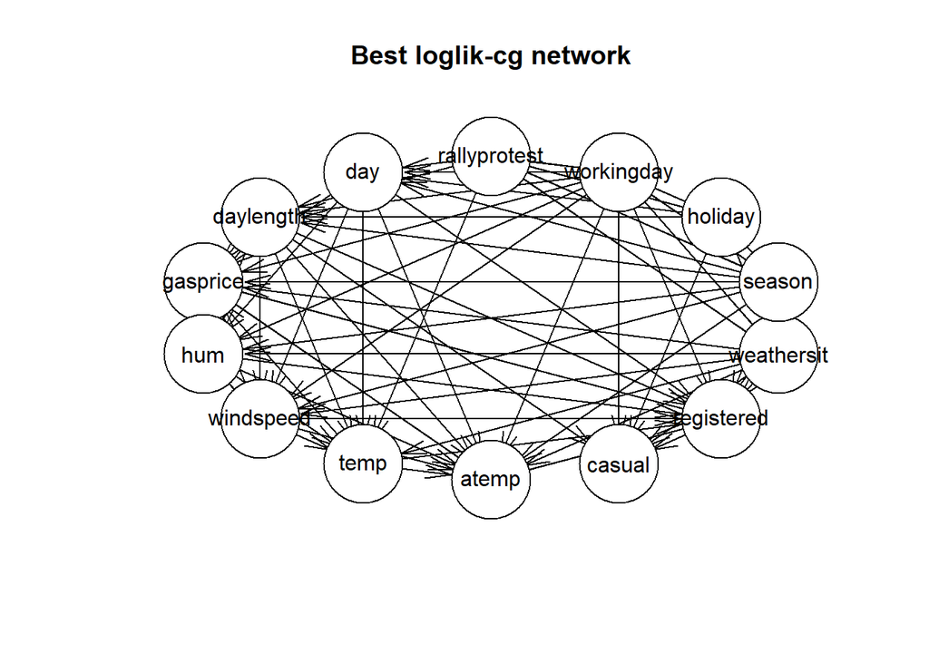

```r
for (i in 1:length(titles)) {
  bestIdx <- metrics["bestSIDidx",i]
  plot(graphs[[i]][[bestIdx]], main=sprintf("Best %s network", titles[i]))
}
```

### PC

Next, we will consider an implementation of the PC algorithm.

```r
# reset list and set alpha thresholds that will be used
graphs <- graphs[1]
alphas = c(0.0001, 0.001, 0.01, 0.05, 0.1)

# run all algorithm variants
n.iters = 1  # number of networks learned per algorithm variant
for (alpha in alphas) {
  run.networks(n.iters, 0, pc.stable, factor.data, alpha=alpha, test="mi-cg")
}
```

We will again inspect the metrics and PageRanks of the learned networks.

```r
# compute and show the metrics and PageRanks
titles = c("manual", paste0("alpha=", alphas))
metrics <- graphsMetrics(titles); print(metrics)
```

```
##                  manual alpha.1e.04 alpha.0.001 alpha.0.01 alpha.0.05
## arcs         24.0000000  11.0000000  13.0000000 10.0000000  9.0000000
## SID           0.0000000  79.0000000  84.0000000 72.0000000 72.0000000
## SHD           0.0000000  28.0000000  29.0000000 30.0000000 29.0000000
## bestSIDidx    1.0000000   1.0000000   1.0000000  1.0000000  1.0000000
## bestSHDidx    1.0000000   1.0000000   1.0000000  1.0000000  1.0000000
## MECs          1.0000000   1.0000000   1.0000000  1.0000000  1.0000000
## DegreeC       0.4102564   0.1282051   0.1025641  0.1410256  0.1538462
## BetweennessC  0.4551282   0.2243590   0.3205128  0.1474359  0.1538462
## TP           24.0000000   8.0000000   9.0000000  8.0000000  7.0000000
## FP            0.0000000   3.0000000   4.0000000  2.0000000  2.0000000
## FN            0.0000000  16.0000000  15.0000000 16.0000000 17.0000000
## TN           67.0000000  64.0000000  63.0000000 65.0000000 65.0000000
## Precision     1.0000000   0.7272727   0.6923077  0.8000000  0.7777778
## Recall        1.0000000   0.3333333   0.3750000  0.3333333  0.2916667
## F1            1.0000000   0.4571429   0.4864865  0.4705882  0.4242424
## DDM           1.0000000  -0.4375000  -0.3958333 -0.4166667 -0.5000000
## BSF           1.0000000   0.2885572   0.3152985  0.3034826  0.2618159
##               alpha.0.1
## arcs          9.0000000
## SID          59.0000000
## SHD          30.0000000
## bestSIDidx    1.0000000
## bestSHDidx    1.0000000
## MECs          1.0000000
## DegreeC       0.1538462
## BetweennessC  0.1602564
## TP            6.0000000
## FP            3.0000000
## FN           18.0000000
## TN           64.0000000
## Precision     0.6666667
## Recall        0.2500000
## F1            0.3636364
## DDM          -0.6041667
## BSF           0.2052239
```

```r
pageRanks <- graphsPageRanks(titles); print(pageRanks)
```

```
##                  manual alpha.1e.04 alpha.0.001 alpha.0.01 alpha.0.05
## day          0.01071429  0.01153846  0.01071429 0.00000000 0.00000000
## season       0.01071429  0.07692308  0.07142857 0.08333333 0.08333333
## holiday      0.01071429  0.00000000  0.01811197 0.02113355 0.02113063
## workingday   0.01071429  0.01153846  0.02610946 0.03046352 0.03046103
## daylength    0.01526786  0.03591674  0.03333180 0.02793101 0.06420004
## rallyprotest 0.01071429  0.07692308  0.07142857 0.08333333 0.08333333
## gasprice     0.01830357  0.04910859  0.04802481 0.00000000 0.00000000
## hum          0.01851228  0.02625000  0.02437500 0.02843750 0.02843750
## windspeed    0.01299107  0.01153846  0.01071429 0.01250000 0.01250000
## temp         0.01504018  0.05731135  0.05323714 0.03624136 0.12159993
## atemp        0.04475508  0.03591674  0.03333180 0.05210289 0.06420004
## casual       0.06992046  0.02134615  0.06348112 0.02644605 0.02644313
## registered   0.05170618  0.02625000  0.02721911 0.02113355 0.02113063
## weathersit   0.01071429  0.01153846  0.01071429 0.01250000 0.01250000
##               alpha.0.1
## day          0.00000000
## season       0.09090909
## holiday      0.02305478
## workingday   0.03323293
## daylength    0.00000000
## rallyprotest 0.09090909
## gasprice     0.00000000
## hum          0.04785656
## windspeed    0.01363636
## temp         0.03047020
## atemp        0.03953603
## casual       0.02885023
## registered   0.02305478
## weathersit   0.01363636
```

Finally, we will inspect the learned networks of the PC algorithm.

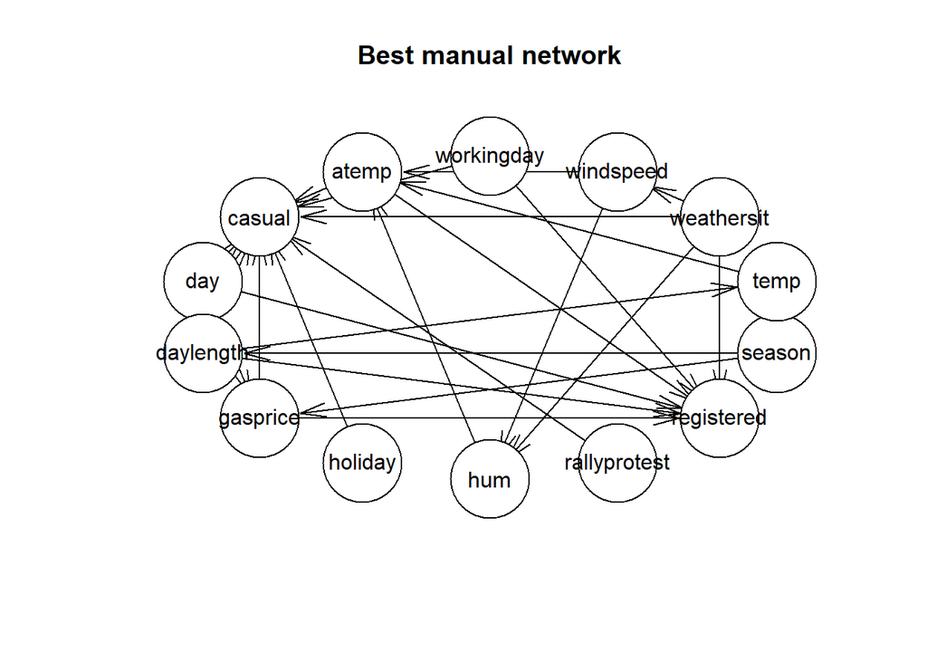

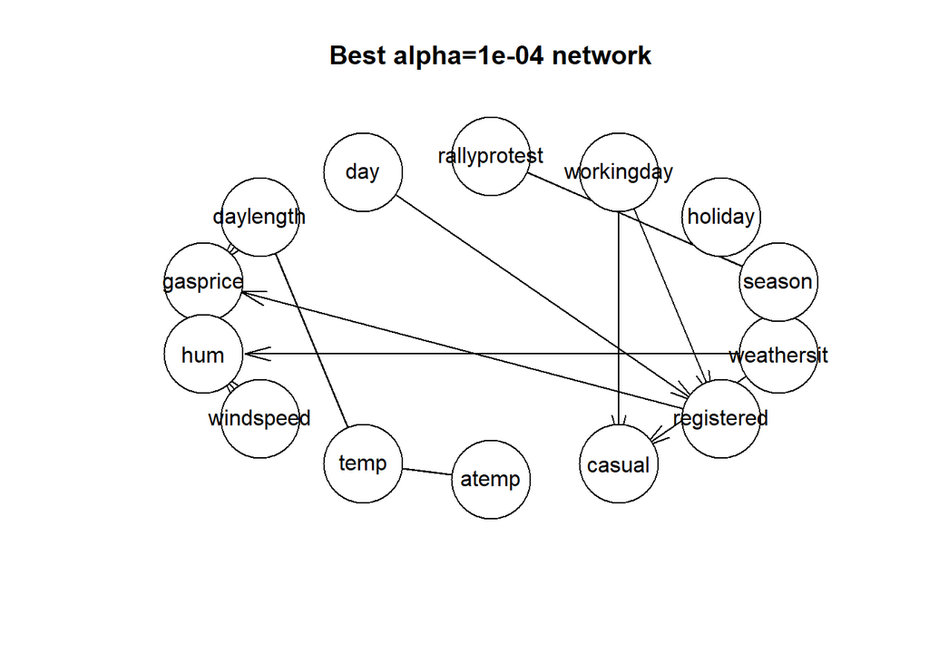

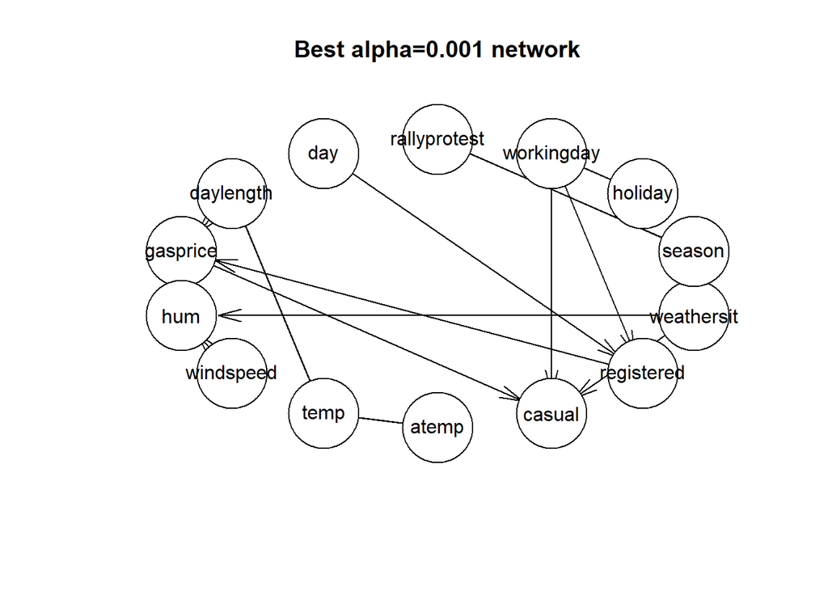

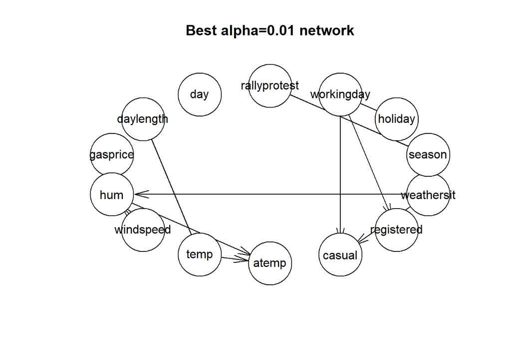

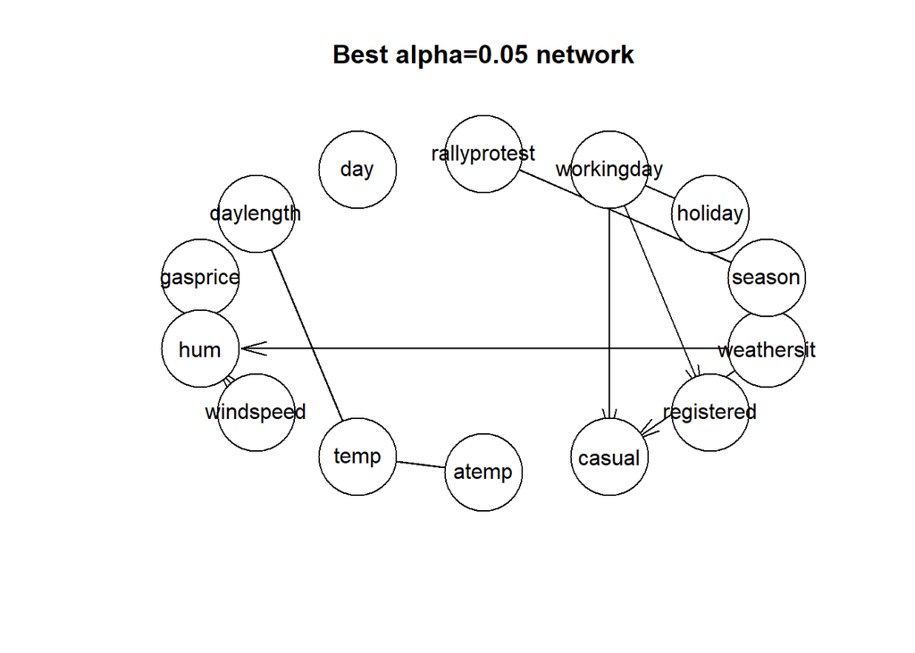

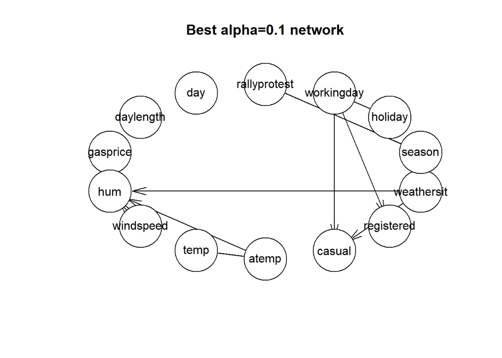

```r
for (i in 1:length(titles)) {
  bestIdx <- metrics["bestSIDidx",i]
  plot(graphs[[i]][[bestIdx]], main=sprintf("Best %s network", titles[i]))
}
```